# Risk Factor Analysis

## Outcome Variable

**Outcome Variable:** pers_wast

## Predictor Variables

**Intervention Variable:** meducyrs

**Adjustment Set:**

- arm
- W_mage
- feducyrs
- hhwealth_quart
- W_mhtcm
- W_gagebrth
- W_birthwt
- W_birthlen
- single
- W_nrooms
- impsan
- delta_W_mage
- delta_feducyrs
- delta_hhwealth_quart
- delta_W_mhtcm
- delta_W_gagebrth
- delta_W_birthwt
- delta_W_birthlen
- delta_single
- delta_W_nrooms
- delta_impsan

## Stratifying Variables

The analysis was stratified on these variable(s):

- agecat
- studyid
- country

## Data Summary

| agecat | studyid | country | meducyrs | pers_wast | n_cell | n |
| --- | --- | --- | --- | --- | --- | --- |
| 0-24 months | ki0047075b-MAL-ED | BANGLADESH | Low | 0 | 62 | 202 |
| 0-24 months | ki0047075b-MAL-ED | BANGLADESH | Low | 1 | 4 | 202 |
| 0-24 months | ki0047075b-MAL-ED | BANGLADESH | Medium | 0 | 59 | 202 |
| 0-24 months | ki0047075b-MAL-ED | BANGLADESH | Medium | 1 | 2 | 202 |
| 0-24 months | ki0047075b-MAL-ED | BANGLADESH | High | 0 | 71 | 202 |
| 0-24 months | ki0047075b-MAL-ED | BANGLADESH | High | 1 | 4 | 202 |
| 0-24 months | ki0047075b-MAL-ED | BRAZIL | Low | 0 | 59 | 216 |
| 0-24 months | ki0047075b-MAL-ED | BRAZIL | Low | 1 | 1 | 216 |
| 0-24 months | ki0047075b-MAL-ED | BRAZIL | Medium | 0 | 81 | 216 |
| 0-24 months | ki0047075b-MAL-ED | BRAZIL | Medium | 1 | 1 | 216 |
| 0-24 months | ki0047075b-MAL-ED | BRAZIL | High | 0 | 74 | 216 |
| 0-24 months | ki0047075b-MAL-ED | BRAZIL | High | 1 | 0 | 216 |
| 0-24 months | ki0047075b-MAL-ED | INDIA | Low | 0 | 63 | 210 |
| 0-24 months | ki0047075b-MAL-ED | INDIA | Low | 1 | 10 | 210 |
| 0-24 months | ki0047075b-MAL-ED | INDIA | Medium | 0 | 72 | 210 |
| 0-24 months | ki0047075b-MAL-ED | INDIA | Medium | 1 | 5 | 210 |
| 0-24 months | ki0047075b-MAL-ED | INDIA | High | 0 | 56 | 210 |
| 0-24 months | ki0047075b-MAL-ED | INDIA | High | 1 | 4 | 210 |
| 0-24 months | ki0047075b-MAL-ED | NEPAL | Low | 0 | 93 | 223 |
| 0-24 months | ki0047075b-MAL-ED | NEPAL | Low | 1 | 1 | 223 |
| 0-24 months | ki0047075b-MAL-ED | NEPAL | Medium | 0 | 74 | 223 |
| 0-24 months | ki0047075b-MAL-ED | NEPAL | Medium | 1 | 2 | 223 |
| 0-24 months | ki0047075b-MAL-ED | NEPAL | High | 0 | 53 | 223 |
| 0-24 months | ki0047075b-MAL-ED | NEPAL | High | 1 | 0 | 223 |
| 0-24 months | ki0047075b-MAL-ED | PERU | Low | 0 | 98 | 283 |
| 0-24 months | ki0047075b-MAL-ED | PERU | Low | 1 | 0 | 283 |
| 0-24 months | ki0047075b-MAL-ED | PERU | Medium | 0 | 99 | 283 |
| 0-24 months | ki0047075b-MAL-ED | PERU | Medium | 1 | 1 | 283 |
| 0-24 months | ki0047075b-MAL-ED | PERU | High | 0 | 85 | 283 |
| 0-24 months | ki0047075b-MAL-ED | PERU | High | 1 | 0 | 283 |

[output cut: 348 more lines]

The following strata were considered:

- agecat: 0-24 months, studyid: ki0047075b-MAL-ED, country: BANGLADESH
- agecat: 0-24 months, studyid: ki0047075b-MAL-ED, country: BRAZIL
- agecat: 0-24 months, studyid: ki0047075b-MAL-ED, country: INDIA
- agecat: 0-24 months, studyid: ki0047075b-MAL-ED, country: NEPAL
- agecat: 0-24 months, studyid: ki0047075b-MAL-ED, country: PERU
- agecat: 0-24 months, studyid: ki0047075b-MAL-ED, country: SOUTH AFRICA
- agecat: 0-24 months, studyid: ki0047075b-MAL-ED, country: TANZANIA, UNITED REPUBLIC OF
- agecat: 0-24 months, studyid: ki1000108-CMC-V-BCS-2002, country: INDIA
- agecat: 0-24 months, studyid: ki1000108-IRC, country: INDIA
- agecat: 0-24 months, studyid: ki1000109-EE, country: PAKISTAN
- agecat: 0-24 months, studyid: ki1000304b-SAS-CompFeed, country: INDIA
- agecat: 0-24 months, studyid: ki1000304b-SAS-FoodSuppl, country: INDIA
- agecat: 0-24 months, studyid: ki1017093-NIH-Birth, country: BANGLADESH
- agecat: 0-24 months, studyid: ki1017093b-PROVIDE, country: BANGLADESH
- agecat: 0-24 months, studyid: ki1017093c-NIH-Crypto, country: BANGLADESH
- agecat: 0-24 months, studyid: ki1066203-TanzaniaChild2, country: TANZANIA, UNITED REPUBLIC OF
- agecat: 0-24 months, studyid: ki1112895-Guatemala BSC, country: GUATEMALA
- agecat: 0-24 months, studyid: ki1113344-GMS-Nepal, country: NEPAL
- agecat: 0-24 months, studyid: ki1119695-PROBIT, country: BELARUS
- agecat: 0-24 months, studyid: ki1126311-ZVITAMBO, country: ZIMBABWE
- agecat: 0-24 months, studyid: ki1135781-COHORTS, country: GUATEMALA
- agecat: 0-24 months, studyid: ki1135781-COHORTS, country: INDIA
- agecat: 0-24 months, studyid: ki1135781-COHORTS, country: PHILIPPINES
- agecat: 0-24 months, studyid: ki1148112-LCNI-5, country: MALAWI
- agecat: 0-24 months, studyid: kiGH5241-JiVitA-3, country: BANGLADESH
- agecat: 0-24 months, studyid: kiGH5241-JiVitA-4, country: BANGLADESH
- agecat: 0-6 months, studyid: ki0047075b-MAL-ED, country: BANGLADESH
- agecat: 0-6 months, studyid: ki0047075b-MAL-ED, country: BRAZIL
- agecat: 0-6 months, studyid: ki0047075b-MAL-ED, country: INDIA
- agecat: 0-6 months, studyid: ki0047075b-MAL-ED, country: NEPAL
- agecat: 0-6 months, studyid: ki0047075b-MAL-ED, country: PERU
- agecat: 0-6 months, studyid: ki0047075b-MAL-ED, country: SOUTH AFRICA
- agecat: 0-6 months, studyid: ki0047075b-MAL-ED, country: TANZANIA, UNITED REPUBLIC OF
- agecat: 0-6 months, studyid: ki1000108-CMC-V-BCS-2002, country: INDIA
- agecat: 0-6 months, studyid: ki1000108-IRC, country: INDIA
- agecat: 0-6 months, studyid: ki1000109-EE, country: PAKISTAN
- agecat: 0-6 months, studyid: ki1017093b-PROVIDE, country: BANGLADESH
- agecat: 0-6 months, studyid: ki1066203-TanzaniaChild2, country: TANZANIA, UNITED REPUBLIC OF
- agecat: 0-6 months, studyid: ki1113344-GMS-Nepal, country: NEPAL
- agecat: 6-24 months, studyid: ki0047075b-MAL-ED, country: BANGLADESH
- agecat: 6-24 months, studyid: ki0047075b-MAL-ED, country: BRAZIL
- agecat: 6-24 months, studyid: ki0047075b-MAL-ED, country: INDIA
- agecat: 6-24 months, studyid: ki0047075b-MAL-ED, country: NEPAL
- agecat: 6-24 months, studyid: ki0047075b-MAL-ED, country: PERU
- agecat: 6-24 months, studyid: ki0047075b-MAL-ED, country: SOUTH AFRICA
- agecat: 6-24 months, studyid: ki0047075b-MAL-ED, country: TANZANIA, UNITED REPUBLIC OF
- agecat: 6-24 months, studyid: ki1000108-CMC-V-BCS-2002, country: INDIA
- agecat: 6-24 months, studyid: ki1000108-IRC, country: INDIA
- agecat: 6-24 months, studyid: ki1000109-EE, country: PAKISTAN
- agecat: 6-24 months, studyid: ki1000304b-SAS-CompFeed, country: INDIA
- agecat: 6-24 months, studyid: ki1000304b-SAS-FoodSuppl, country: INDIA
- agecat: 6-24 months, studyid: ki1017093-NIH-Birth, country: BANGLADESH
- agecat: 6-24 months, studyid: ki1017093b-PROVIDE, country: BANGLADESH
- agecat: 6-24 months, studyid: ki1017093c-NIH-Crypto, country: BANGLADESH
- agecat: 6-24 months, studyid: ki1066203-TanzaniaChild2, country: TANZANIA, UNITED REPUBLIC OF
- agecat: 6-24 months, studyid: ki1112895-Guatemala BSC, country: GUATEMALA
- agecat: 6-24 months, studyid: ki1113344-GMS-Nepal, country: NEPAL
- agecat: 6-24 months, studyid: ki1119695-PROBIT, country: BELARUS
- agecat: 6-24 months, studyid: ki1126311-ZVITAMBO, country: ZIMBABWE
- agecat: 6-24 months, studyid: ki1135781-COHORTS, country: GUATEMALA
- agecat: 6-24 months, studyid: ki1135781-COHORTS, country: PHILIPPINES
- agecat: 6-24 months, studyid: ki1148112-LCNI-5, country: MALAWI
- agecat: 6-24 months, studyid: kiGH5241-JiVitA-4, country: BANGLADESH

### Dropped Strata

Some strata were dropped due to rare outcomes:

- agecat: 0-24 months, studyid: ki0047075b-MAL-ED, country: BANGLADESH
- agecat: 0-24 months, studyid: ki0047075b-MAL-ED, country: BRAZIL
- agecat: 0-24 months, studyid: ki0047075b-MAL-ED, country: INDIA
- agecat: 0-24 months, studyid: ki0047075b-MAL-ED, country: NEPAL
- agecat: 0-24 months, studyid: ki0047075b-MAL-ED, country: PERU
- agecat: 0-24 months, studyid: ki0047075b-MAL-ED, country: SOUTH AFRICA
- agecat: 0-24 months, studyid: ki0047075b-MAL-ED, country: TANZANIA, UNITED REPUBLIC OF
- agecat: 0-24 months, studyid: ki1000109-EE, country: PAKISTAN
- agecat: 0-24 months, studyid: ki1000304b-SAS-FoodSuppl, country: INDIA
- agecat: 0-24 months, studyid: ki1017093b-PROVIDE, country: BANGLADESH
- agecat: 0-24 months, studyid: ki1017093c-NIH-Crypto, country: BANGLADESH
- agecat: 0-24 months, studyid: ki1066203-TanzaniaChild2, country: TANZANIA, UNITED REPUBLIC OF
- agecat: 0-24 months, studyid: ki1112895-Guatemala BSC, country: GUATEMALA
- agecat: 0-24 months, studyid: ki1148112-LCNI-5, country: MALAWI
- agecat: 0-6 months, studyid: ki0047075b-MAL-ED, country: BANGLADESH
- agecat: 0-6 months, studyid: ki0047075b-MAL-ED, country: BRAZIL
- agecat: 0-6 months, studyid: ki0047075b-MAL-ED, country: NEPAL
- agecat: 0-6 months, studyid: ki0047075b-MAL-ED, country: PERU
- agecat: 0-6 months, studyid: ki0047075b-MAL-ED, country: SOUTH AFRICA
- agecat: 0-6 months, studyid: ki0047075b-MAL-ED, country: TANZANIA, UNITED REPUBLIC OF
- agecat: 0-6 months, studyid: ki1000109-EE, country: PAKISTAN
- agecat: 0-6 months, studyid: ki1017093b-PROVIDE, country: BANGLADESH
- agecat: 0-6 months, studyid: ki1066203-TanzaniaChild2, country: TANZANIA, UNITED REPUBLIC OF
- agecat: 6-24 months, studyid: ki0047075b-MAL-ED, country: BANGLADESH
- agecat: 6-24 months, studyid: ki0047075b-MAL-ED, country: BRAZIL
- agecat: 6-24 months, studyid: ki0047075b-MAL-ED, country: INDIA
- agecat: 6-24 months, studyid: ki0047075b-MAL-ED, country: NEPAL
- agecat: 6-24 months, studyid: ki0047075b-MAL-ED, country: PERU
- agecat: 6-24 months, studyid: ki0047075b-MAL-ED, country: SOUTH AFRICA
- agecat: 6-24 months, studyid: ki0047075b-MAL-ED, country: TANZANIA, UNITED REPUBLIC OF
- agecat: 6-24 months, studyid: ki1000109-EE, country: PAKISTAN
- agecat: 6-24 months, studyid: ki1000304b-SAS-FoodSuppl, country: INDIA
- agecat: 6-24 months, studyid: ki1066203-TanzaniaChild2, country: TANZANIA, UNITED REPUBLIC OF
- agecat: 6-24 months, studyid: ki1112895-Guatemala BSC, country: GUATEMALA
- agecat: 6-24 months, studyid: ki1119695-PROBIT, country: BELARUS
- agecat: 6-24 months, studyid: ki1148112-LCNI-5, country: MALAWI

## Methods Detail

We’re interested in the causal parameters $E[Y_a]$ for all values of $a \in \mathcal{A}$. These parameters represent the mean outcome if, possibly contrary to fact, we intervened to set all units to have $A=a$. Under the randomization and positivity assumptions, these are identified by the statistical parameters $\psi_a=E_W[E_{Y|A,W}(Y|A=a,W)]$. In addition, we’re interested in the mean of $Y$, $E[Y]$ under no intervention (the observed mean). We will estimate these parameters by using SuperLearner to fit the relevant likelihood factors – $E_{Y|A,W}(Y|A=a,W)$ and $p(A=a|W)$, and then updating our likelihood fit using a joint TMLE.

For unadjusted analyses ($W=\{\}$), initial likelihoods were estimated using Lrnr_glm to estimate the simple $E(Y|A)$ and Lrnr_mean to estimate $p(A)$. For adjusted analyses, a small library containing Lrnr_glmnet, Lrnr_xgboost, and Lrnr_mean was used.

Having estimated these parameters, we will then use the delta method to estimate relative risks and attributable risks relative to a prespecified baseline level of $A$.

# Results Detail

## Results Plots

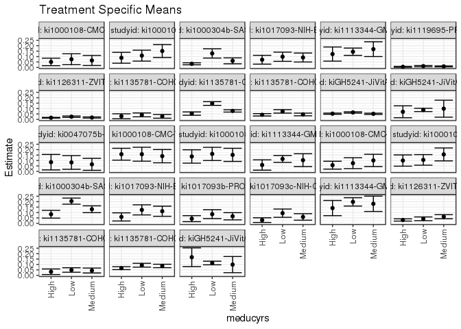

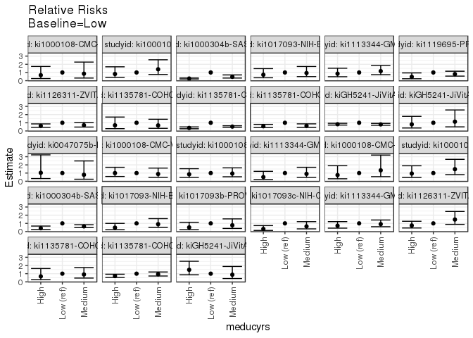

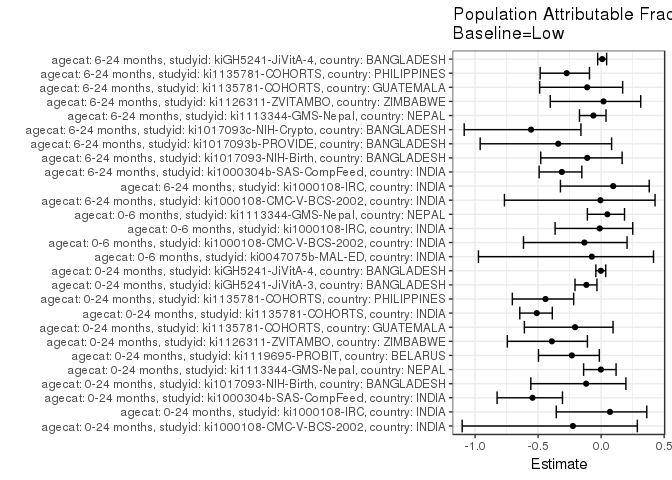

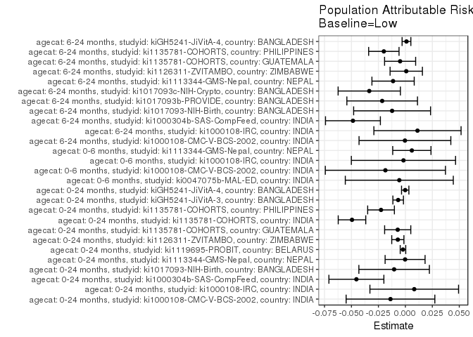

## Results Table

### Parameter: TSM

| agecat | studyid | country | intervention_level | baseline_level | estimate | ci_lower | ci_upper |
| --- | --- | --- | --- | --- | --- | --- | --- |
| 0-24 months | ki1000108-CMC-V-BCS-2002 | INDIA | Low | NA | 0.0754717 | 0.0251181 | 0.1258253 |
| 0-24 months | ki1000108-CMC-V-BCS-2002 | INDIA | Medium | NA | 0.0642202 | 0.0181372 | 0.1103031 |
| 0-24 months | ki1000108-CMC-V-BCS-2002 | INDIA | High | NA | 0.0506329 | 0.0164006 | 0.0848652 |
| 0-24 months | ki1000108-IRC | INDIA | Low | NA | 0.1088441 | 0.0584375 | 0.1592508 |
| 0-24 months | ki1000108-IRC | INDIA | Medium | NA | 0.1510721 | 0.0914626 | 0.2106815 |
| 0-24 months | ki1000108-IRC | INDIA | High | NA | 0.0887141 | 0.0386104 | 0.1388177 |
| 0-24 months | ki1000304b-SAS-CompFeed | INDIA | Low | NA | 0.1288805 | 0.0861615 | 0.1715994 |
| 0-24 months | ki1000304b-SAS-CompFeed | INDIA | Medium | NA | 0.0607610 | 0.0334512 | 0.0880708 |
| 0-24 months | ki1000304b-SAS-CompFeed | INDIA | High | NA | 0.0332202 | 0.0240955 | 0.0423448 |
| 0-24 months | ki1017093-NIH-Birth | BANGLADESH | Low | NA | 0.0984456 | 0.0563758 | 0.1405154 |
| 0-24 months | ki1017093-NIH-Birth | BANGLADESH | Medium | NA | 0.0913978 | 0.0499451 | 0.1328506 |
| 0-24 months | ki1017093-NIH-Birth | BANGLADESH | High | NA | 0.0709677 | 0.0305069 | 0.1114286 |
| 0-24 months | ki1113344-GMS-Nepal | NEPAL | Low | NA | 0.1445755 | 0.1109006 | 0.1782504 |
| 0-24 months | ki1113344-GMS-Nepal | NEPAL | Medium | NA | 0.1683346 | 0.1002871 | 0.2363820 |
| 0-24 months | ki1113344-GMS-Nepal | NEPAL | High | NA | 0.1231959 | 0.0581093 | 0.1882824 |
| 0-24 months | ki1119695-PROBIT | BELARUS | Low | NA | 0.0118149 | 0.0059197 | 0.0177101 |
| 0-24 months | ki1119695-PROBIT | BELARUS | Medium | NA | 0.0094345 | 0.0050383 | 0.0138306 |
| 0-24 months | ki1119695-PROBIT | BELARUS | High | NA | 0.0055528 | 0.0012980 | 0.0098077 |
| 0-24 months | ki1126311-ZVITAMBO | ZIMBABWE | Low | NA | 0.0249187 | 0.0184542 | 0.0313832 |
| 0-24 months | ki1126311-ZVITAMBO | ZIMBABWE | Medium | NA | 0.0174914 | 0.0124642 | 0.0225186 |
| 0-24 months | ki1126311-ZVITAMBO | ZIMBABWE | High | NA | 0.0153913 | 0.0121557 | 0.0186269 |
| 0-24 months | ki1135781-COHORTS | GUATEMALA | Low | NA | 0.0414938 | 0.0236814 | 0.0593061 |
| 0-24 months | ki1135781-COHORTS | GUATEMALA | Medium | NA | 0.0280899 | 0.0109180 | 0.0452618 |
| 0-24 months | ki1135781-COHORTS | GUATEMALA | High | NA | 0.0287081 | 0.0060586 | 0.0513577 |
| 0-24 months | ki1135781-COHORTS | INDIA | Low | NA | 0.1464285 | 0.1294280 | 0.1634289 |
| 0-24 months | ki1135781-COHORTS | INDIA | Medium | NA | 0.0780138 | 0.0676314 | 0.0883963 |
| 0-24 months | ki1135781-COHORTS | INDIA | High | NA | 0.0533697 | 0.0381570 | 0.0685825 |
| 0-24 months | ki1135781-COHORTS | PHILIPPINES | Low | NA | 0.0738022 | 0.0580390 | 0.0895655 |
| 0-24 months | ki1135781-COHORTS | PHILIPPINES | Medium | NA | 0.0455761 | 0.0334707 | 0.0576815 |
| 0-24 months | ki1135781-COHORTS | PHILIPPINES | High | NA | 0.0424986 | 0.0314868 | 0.0535104 |

[output cut: 51 more lines]

### Parameter: E(Y)

| agecat | studyid | country | intervention_level | baseline_level | estimate | ci_lower | ci_upper |
| --- | --- | --- | --- | --- | --- | --- | --- |
| 0-24 months | ki1000108-CMC-V-BCS-2002 | INDIA | NA | NA | 0.0616622 | 0.0372186 | 0.0861058 |
| 0-24 months | ki1000108-IRC | INDIA | NA | NA | 0.1170732 | 0.0859146 | 0.1482317 |
| 0-24 months | ki1000304b-SAS-CompFeed | INDIA | NA | NA | 0.0834553 | 0.0601989 | 0.1067118 |
| 0-24 months | ki1017093-NIH-Birth | BANGLADESH | NA | NA | 0.0880150 | 0.0639627 | 0.1120673 |
| 0-24 months | ki1113344-GMS-Nepal | NEPAL | NA | NA | 0.1443124 | 0.1159091 | 0.1727157 |
| 0-24 months | ki1119695-PROBIT | BELARUS | NA | NA | 0.0095893 | 0.0052864 | 0.0138922 |
| 0-24 months | ki1126311-ZVITAMBO | ZIMBABWE | NA | NA | 0.0179204 | 0.0152268 | 0.0206140 |
| 0-24 months | ki1135781-COHORTS | GUATEMALA | NA | NA | 0.0343840 | 0.0233416 | 0.0454263 |
| 0-24 months | ki1135781-COHORTS | INDIA | NA | NA | 0.0969241 | 0.0882972 | 0.1055510 |
| 0-24 months | ki1135781-COHORTS | PHILIPPINES | NA | NA | 0.0512273 | 0.0430760 | 0.0593786 |
| 0-24 months | kiGH5241-JiVitA-3 | BANGLADESH | NA | NA | 0.0572614 | 0.0531676 | 0.0613553 |
| 0-24 months | kiGH5241-JiVitA-4 | BANGLADESH | NA | NA | 0.0868770 | 0.0725284 | 0.1012256 |
| 0-6 months | ki0047075b-MAL-ED | INDIA | NA | NA | 0.0765550 | 0.0404216 | 0.1126884 |
| 0-6 months | ki1000108-CMC-V-BCS-2002 | INDIA | NA | NA | 0.1396648 | 0.1037072 | 0.1756225 |
| 0-6 months | ki1000108-IRC | INDIA | NA | NA | 0.1592040 | 0.1233945 | 0.1950135 |
| 0-6 months | ki1113344-GMS-Nepal | NEPAL | NA | NA | 0.1205937 | 0.0930759 | 0.1481115 |
| 6-24 months | ki1000108-CMC-V-BCS-2002 | INDIA | NA | NA | 0.0750670 | 0.0482904 | 0.1018437 |
| 6-24 months | ki1000108-IRC | INDIA | NA | NA | 0.1170732 | 0.0859146 | 0.1482317 |
| 6-24 months | ki1000304b-SAS-CompFeed | INDIA | NA | NA | 0.1561462 | 0.1410608 | 0.1712315 |
| 6-24 months | ki1017093-NIH-Birth | BANGLADESH | NA | NA | 0.1117886 | 0.0839169 | 0.1396604 |
| 6-24 months | ki1017093b-PROVIDE | BANGLADESH | NA | NA | 0.0632280 | 0.0437545 | 0.0827015 |
| 6-24 months | ki1017093c-NIH-Crypto | BANGLADESH | NA | NA | 0.0602582 | 0.0425793 | 0.0779372 |
| 6-24 months | ki1113344-GMS-Nepal | NEPAL | NA | NA | 0.1864111 | 0.1545245 | 0.2182978 |
| 6-24 months | ki1126311-ZVITAMBO | ZIMBABWE | NA | NA | 0.0426966 | 0.0342942 | 0.0510990 |
| 6-24 months | ki1135781-COHORTS | GUATEMALA | NA | NA | 0.0441810 | 0.0309524 | 0.0574096 |
| 6-24 months | ki1135781-COHORTS | PHILIPPINES | NA | NA | 0.0731338 | 0.0631985 | 0.0830690 |
| 6-24 months | kiGH5241-JiVitA-4 | BANGLADESH | NA | NA | 0.1144349 | 0.0983098 | 0.1305601 |

### Parameter: RR

| agecat | studyid | country | intervention_level | baseline_level | estimate | ci_lower | ci_upper |
| --- | --- | --- | --- | --- | --- | --- | --- |
| 0-24 months | ki1000108-CMC-V-BCS-2002 | INDIA | Low | Low | 1.0000000 | 1.0000000 | 1.0000000 |
| 0-24 months | ki1000108-CMC-V-BCS-2002 | INDIA | Medium | Low | 0.8509174 | 0.3194153 | 2.2668310 |
| 0-24 months | ki1000108-CMC-V-BCS-2002 | INDIA | High | Low | 0.6708861 | 0.2594960 | 1.7344704 |
| 0-24 months | ki1000108-IRC | INDIA | Low | Low | 1.0000000 | 1.0000000 | 1.0000000 |
| 0-24 months | ki1000108-IRC | INDIA | Medium | Low | 1.3879667 | 0.7553558 | 2.5503895 |
| 0-24 months | ki1000108-IRC | INDIA | High | Low | 0.8150561 | 0.3926405 | 1.6919200 |
| 0-24 months | ki1000304b-SAS-CompFeed | INDIA | Low | Low | 1.0000000 | 1.0000000 | 1.0000000 |
| 0-24 months | ki1000304b-SAS-CompFeed | INDIA | Medium | Low | 0.4714524 | 0.3172357 | 0.7006379 |
| 0-24 months | ki1000304b-SAS-CompFeed | INDIA | High | Low | 0.2577596 | 0.2053916 | 0.3234796 |
| 0-24 months | ki1017093-NIH-Birth | BANGLADESH | Low | Low | 1.0000000 | 1.0000000 | 1.0000000 |
| 0-24 months | ki1017093-NIH-Birth | BANGLADESH | Medium | Low | 0.9284097 | 0.4978603 | 1.7312982 |
| 0-24 months | ki1017093-NIH-Birth | BANGLADESH | High | Low | 0.7208829 | 0.3535298 | 1.4699525 |
| 0-24 months | ki1113344-GMS-Nepal | NEPAL | Low | Low | 1.0000000 | 1.0000000 | 1.0000000 |
| 0-24 months | ki1113344-GMS-Nepal | NEPAL | Medium | Low | 1.1643367 | 0.7303546 | 1.8561942 |
| 0-24 months | ki1113344-GMS-Nepal | NEPAL | High | Low | 0.8521213 | 0.4782898 | 1.5181398 |
| 0-24 months | ki1119695-PROBIT | BELARUS | Low | Low | 1.0000000 | 1.0000000 | 1.0000000 |
| 0-24 months | ki1119695-PROBIT | BELARUS | Medium | Low | 0.7985202 | 0.5531348 | 1.1527650 |
| 0-24 months | ki1119695-PROBIT | BELARUS | High | Low | 0.4699846 | 0.2333225 | 0.9466961 |
| 0-24 months | ki1126311-ZVITAMBO | ZIMBABWE | Low | Low | 1.0000000 | 1.0000000 | 1.0000000 |
| 0-24 months | ki1126311-ZVITAMBO | ZIMBABWE | Medium | Low | 0.7019394 | 0.4770082 | 1.0329360 |
| 0-24 months | ki1126311-ZVITAMBO | ZIMBABWE | High | Low | 0.6176603 | 0.4426983 | 0.8617702 |
| 0-24 months | ki1135781-COHORTS | GUATEMALA | Low | Low | 1.0000000 | 1.0000000 | 1.0000000 |
| 0-24 months | ki1135781-COHORTS | GUATEMALA | Medium | Low | 0.6769663 | 0.3207408 | 1.4288278 |
| 0-24 months | ki1135781-COHORTS | GUATEMALA | High | Low | 0.6918660 | 0.2818027 | 1.6986303 |
| 0-24 months | ki1135781-COHORTS | INDIA | Low | Low | 1.0000000 | 1.0000000 | 1.0000000 |
| 0-24 months | ki1135781-COHORTS | INDIA | Medium | Low | 0.5327779 | 0.4468624 | 0.6352117 |
| 0-24 months | ki1135781-COHORTS | INDIA | High | Low | 0.3644764 | 0.2680613 | 0.4955698 |
| 0-24 months | ki1135781-COHORTS | PHILIPPINES | Low | Low | 1.0000000 | 1.0000000 | 1.0000000 |
| 0-24 months | ki1135781-COHORTS | PHILIPPINES | Medium | Low | 0.6175437 | 0.4392486 | 0.8682103 |
| 0-24 months | ki1135781-COHORTS | PHILIPPINES | High | Low | 0.5758443 | 0.4117506 | 0.8053337 |

[output cut: 51 more lines]

### Parameter: PAR

| agecat | studyid | country | intervention_level | baseline_level | estimate | ci_lower | ci_upper |
| --- | --- | --- | --- | --- | --- | --- | --- |
| 0-24 months | ki1000108-CMC-V-BCS-2002 | INDIA | Low | NA | -0.0138095 | -0.0549421 | 0.0273232 |
| 0-24 months | ki1000108-IRC | INDIA | Low | NA | 0.0082290 | -0.0328767 | 0.0493347 |
| 0-24 months | ki1000304b-SAS-CompFeed | INDIA | Low | NA | -0.0454251 | -0.0709084 | -0.0199419 |
| 0-24 months | ki1017093-NIH-Birth | BANGLADESH | Low | NA | -0.0104306 | -0.0431268 | 0.0222655 |
| 0-24 months | ki1113344-GMS-Nepal | NEPAL | Low | NA | -0.0002631 | -0.0187907 | 0.0182645 |
| 0-24 months | ki1119695-PROBIT | BELARUS | Low | NA | -0.0022256 | -0.0047839 | 0.0003327 |
| 0-24 months | ki1126311-ZVITAMBO | ZIMBABWE | Low | NA | -0.0069983 | -0.0126395 | -0.0013572 |
| 0-24 months | ki1135781-COHORTS | GUATEMALA | Low | NA | -0.0071098 | -0.0192377 | 0.0050181 |
| 0-24 months | ki1135781-COHORTS | INDIA | Low | NA | -0.0495044 | -0.0622697 | -0.0367390 |
| 0-24 months | ki1135781-COHORTS | PHILIPPINES | Low | NA | -0.0225749 | -0.0349644 | -0.0101855 |
| 0-24 months | kiGH5241-JiVitA-3 | BANGLADESH | Low | NA | -0.0066867 | -0.0115841 | -0.0017892 |
| 0-24 months | kiGH5241-JiVitA-4 | BANGLADESH | Low | NA | -0.0001469 | -0.0035482 | 0.0032545 |
| 0-6 months | ki0047075b-MAL-ED | INDIA | Low | NA | -0.0056368 | -0.0557164 | 0.0444429 |
| 0-6 months | ki1000108-CMC-V-BCS-2002 | INDIA | Low | NA | -0.0185362 | -0.0742484 | 0.0371760 |
| 0-6 months | ki1000108-IRC | INDIA | Low | NA | -0.0017781 | -0.0500984 | 0.0465422 |
| 0-6 months | ki1113344-GMS-Nepal | NEPAL | Low | NA | 0.0060010 | -0.0117420 | 0.0237439 |
| 6-24 months | ki1000108-CMC-V-BCS-2002 | INDIA | Low | NA | -0.0004047 | -0.0429651 | 0.0421558 |
| 6-24 months | ki1000108-IRC | INDIA | Low | NA | 0.0112197 | -0.0292102 | 0.0516495 |
| 6-24 months | ki1000304b-SAS-CompFeed | INDIA | Low | NA | -0.0486279 | -0.0740755 | -0.0231803 |
| 6-24 months | ki1017093-NIH-Birth | BANGLADESH | Low | NA | -0.0123097 | -0.0479710 | 0.0233515 |
| 6-24 months | ki1017093b-PROVIDE | BANGLADESH | Low | NA | -0.0215178 | -0.0542624 | 0.0112268 |
| 6-24 months | ki1017093c-NIH-Crypto | BANGLADESH | Low | NA | -0.0334918 | -0.0623675 | -0.0046160 |
| 6-24 months | ki1113344-GMS-Nepal | NEPAL | Low | NA | -0.0114083 | -0.0310190 | 0.0082025 |
| 6-24 months | ki1126311-ZVITAMBO | ZIMBABWE | Low | NA | 0.0008084 | -0.0141846 | 0.0158014 |
| 6-24 months | ki1135781-COHORTS | GUATEMALA | Low | NA | -0.0048844 | -0.0192900 | 0.0095212 |
| 6-24 months | ki1135781-COHORTS | PHILIPPINES | Low | NA | -0.0199718 | -0.0340559 | -0.0058877 |
| 6-24 months | kiGH5241-JiVitA-4 | BANGLADESH | Low | NA | 0.0010191 | -0.0030440 | 0.0050822 |

### Parameter: PAF

| agecat | studyid | country | intervention_level | baseline_level | estimate | ci_lower | ci_upper |
| --- | --- | --- | --- | --- | --- | --- | --- |
| 0-24 months | ki1000108-CMC-V-BCS-2002 | INDIA | Low | NA | -0.2239541 | -1.1022934 | 0.2874146 |
| 0-24 months | ki1000108-IRC | INDIA | Low | NA | 0.0702896 | -0.3557704 | 0.3624574 |
| 0-24 months | ki1000304b-SAS-CompFeed | INDIA | Low | NA | -0.5443044 | -0.8253019 | -0.3065653 |
| 0-24 months | ki1017093-NIH-Birth | BANGLADESH | Low | NA | -0.1185095 | -0.5575749 | 0.1967875 |
| 0-24 months | ki1113344-GMS-Nepal | NEPAL | Low | NA | -0.0018232 | -0.1388050 | 0.1186816 |
| 0-24 months | ki1119695-PROBIT | BELARUS | Low | NA | -0.2320955 | -0.4969569 | -0.0140968 |
| 0-24 months | ki1126311-ZVITAMBO | ZIMBABWE | Low | NA | -0.3905230 | -0.7440855 | -0.1086350 |
| 0-24 months | ki1135781-COHORTS | GUATEMALA | Low | NA | -0.2067773 | -0.6087574 | 0.0947600 |
| 0-24 months | ki1135781-COHORTS | INDIA | Low | NA | -0.5107540 | -0.6452701 | -0.3872359 |
| 0-24 months | ki1135781-COHORTS | PHILIPPINES | Low | NA | -0.4406813 | -0.7043242 | -0.2178216 |
| 0-24 months | kiGH5241-JiVitA-3 | BANGLADESH | Low | NA | -0.1167744 | -0.2072312 | -0.0330954 |
| 0-24 months | kiGH5241-JiVitA-4 | BANGLADESH | Low | NA | -0.0016909 | -0.0415998 | 0.0366889 |
| 0-6 months | ki0047075b-MAL-ED | INDIA | Low | NA | -0.0736301 | -0.9731690 | 0.4158221 |
| 0-6 months | ki1000108-CMC-V-BCS-2002 | INDIA | Low | NA | -0.1327192 | -0.6158579 | 0.2059619 |
| 0-6 months | ki1000108-IRC | INDIA | Low | NA | -0.0111686 | -0.3650867 | 0.2509912 |
| 0-6 months | ki1113344-GMS-Nepal | NEPAL | Low | NA | 0.0497618 | -0.1089605 | 0.1857666 |
| 6-24 months | ki1000108-CMC-V-BCS-2002 | INDIA | Low | NA | -0.0053908 | -0.7670293 | 0.4279604 |
| 6-24 months | ki1000108-IRC | INDIA | Low | NA | 0.0958347 | -0.3226557 | 0.3819141 |
| 6-24 months | ki1000304b-SAS-CompFeed | INDIA | Low | NA | -0.3114256 | -0.4916494 | -0.1529768 |
| 6-24 months | ki1017093-NIH-Birth | BANGLADESH | Low | NA | -0.1101163 | -0.4791300 | 0.1668358 |
| 6-24 months | ki1017093b-PROVIDE | BANGLADESH | Low | NA | -0.3403211 | -0.9596355 | 0.0832679 |
| 6-24 months | ki1017093c-NIH-Crypto | BANGLADESH | Low | NA | -0.5558036 | -1.0862710 | -0.1602159 |
| 6-24 months | ki1113344-GMS-Nepal | NEPAL | Low | NA | -0.0611995 | -0.1717207 | 0.0388968 |
| 6-24 months | ki1126311-ZVITAMBO | ZIMBABWE | Low | NA | 0.0189342 | -0.4033490 | 0.3141477 |
| 6-24 months | ki1135781-COHORTS | GUATEMALA | Low | NA | -0.1105539 | -0.4875023 | 0.1708719 |
| 6-24 months | ki1135781-COHORTS | PHILIPPINES | Low | NA | -0.2730860 | -0.4838179 | -0.0922823 |
| 6-24 months | kiGH5241-JiVitA-4 | BANGLADESH | Low | NA | 0.0089056 | -0.0273139 | 0.0438482 |